# Evolution of virulence

26 April 2016

## parasite ecology & evolution

## why study parasite eco/evo?

- cool natural history
- drives ecological communities  
  (e.g. Janzen-Connell, apparent competition)
- interesting ecological systems
- conservation/  
  wildlife management/  
  agricultural impact
- human health

## what is a parasite?

- *natural enemy - victim* interaction (parasite gains, host loses)
- - close association (*symbiosis*)
- - doesn't kill host  
    (prolonged interaction)

|  | kills host | doesn't kill host |
| --- | --- | --- |
| **non-symbiotic** | predator | grazer |
| **symbiotic** | parasitoid | parasite |

## enemy-victim interactions

- mix of positive and negative feedback
- interesting dynamics
  - ecology: cycles
  - (co)evolution: *Red Queen* cycles

## chasing the Red Queen: recognition and evasion

- maintenance of sex  
  (Ebert et al. 1996)
- clonal replacement (Lively)
- sexual selection:
  - ornamentation: Hamilton-Zuk
  - immunocompetence handicap: Folstad
  - MHC-based selection: Penn and Potts

[figure not shown]

## from Red Queen to arms races

- changing metaphors
- variable recognition (e.g. antibodies)
- conserved *effectors* (e.g. apoptosis, killer cells, melanization …)
- suppose *recognition* is unavoidable
- choice is in *strength* of effector response

[figure not shown]

## evolution of virulence

## historical stages

- "classical dogma"
- Ewald era: verbal tradeoff theory
- post-Ewald: mathematical tradeoff theory
- modern: diversity of concerns

## defining virulence

- harm to host (= loss of host fitness)
- … in a **reference** host  
  (*warning*: host \(\times\) parasite interaction?)
- special cases (Day 2002a)
  - case mortality
  - loss of fecundity (castration)
  - debilitation
  - disease-induced mortality **rate**
- alternate definition in plant epidemiology

## physiology of virulence

- **why** are parasites virulent, and what connects virulence to between-host dynamics?
- replication rate/efficiency \(\to\) parasite load
- faster use of host resources (cells/nutrients)
- immunopathology: virulence connection with **clearance**

## resistance, and tolerance

- **resistance**: avoid infection or reduce load
- **tolerance**: reduce fitness cost per unit load
- qualitatively different evolutionary dynamics (Roy et al. 2000)
- 4-way interaction: (resistance \(\times\) tolerance \(\times\) exploitation \(\times\) pathogenicity)

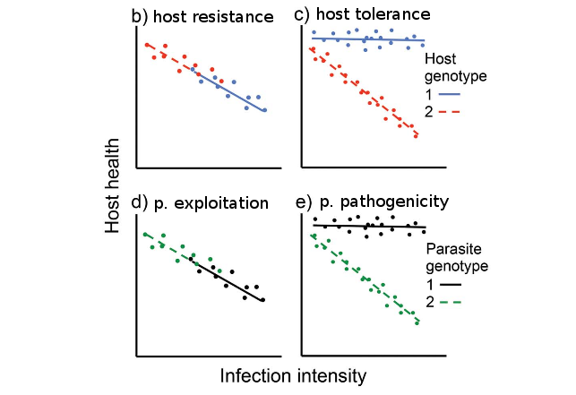

(after Råberg (2014))

## classical dogma (Levin et al. 1990)

- parasites evolve to minimize virulence
- over evolutionary time, become *commensal*
- naively group selectionist
- anecdotal: sampling bias?
  - syphilis (Knell 2004)
  - myxomatosis (Dwyer et al. 1990)
  - virgin-soil epidemics

## Paul Ewald

- popularized idea of *virulence management*
- environmental vs direct  
  (e.g. cholera)
- horizontal vs vertical  
  (e.g. needle/sex vs maternal)
- effect of transmission rate (e.g. 1918 flu)
- mostly correlative

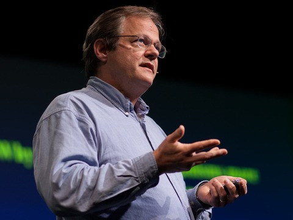

## modes of transmission

- does virulence favor or disfavor transmission?
- vertical vs horizontal e.g. lytic vs non-lytic phage, sigma virus
- active
  - e.g. rabies; aerosol spread by sneezing
- necro-transmission (anthrax) (Day 2002b)
- trophic
- vector
- iatrogenic/nosocomial
- generally hard to manipulate

## post-Ewald

- **tradeoff theory**
- from verbal to mathematical theory
- e.g. *adaptive dynamics*

[figure not shown]

## tradeoff theory

- individual, not population, as unit of selection
- assumed *tradeoff curve*
- virulence = rate of host mortality
- transmission *rate* increases with virulence …
- but with diminishing returns

## the tradeoff curve

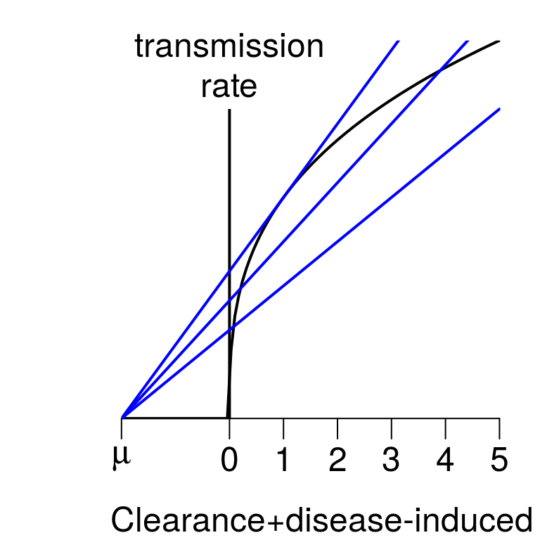

\[ \begin{split} {\mathcal R}_0 & = \frac{\beta(\alpha) N}{\mu+\alpha} \\ \beta'(\alpha) & = \frac{\beta(\alpha)}{\mu+\alpha} \end{split} \]

## other assumptions of tradeoff theory

- host as homogeneous "bags of resources"; no evolution
- no host heterogeneity
- one parasite lineage per host
  - no superinfection or coinfection
  - no within-host mutation
  - no within-host conflict
- fixed host population size

## tradeoff curves

- rarely measured

## malaria

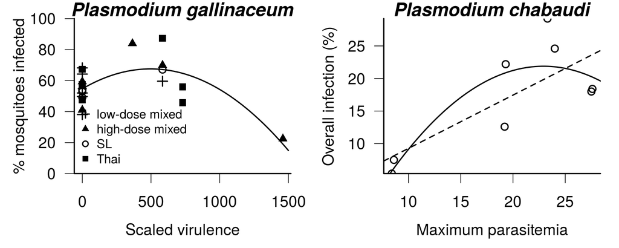

- Mackinnon et al. (1999), Paul et al. (2004)
- transmission (y-axis) in percent infection
- often using virulence *proxies*: anemia

## *Pasteuria ramosa*

- Jensen et al. (2006)
- *castrating* parasite  
  (so "host fitness" is decoupled)

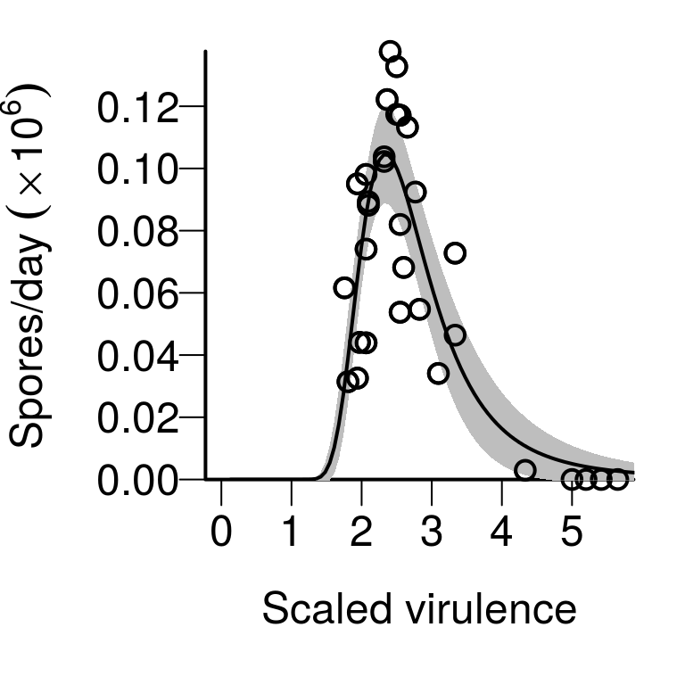

## HIV

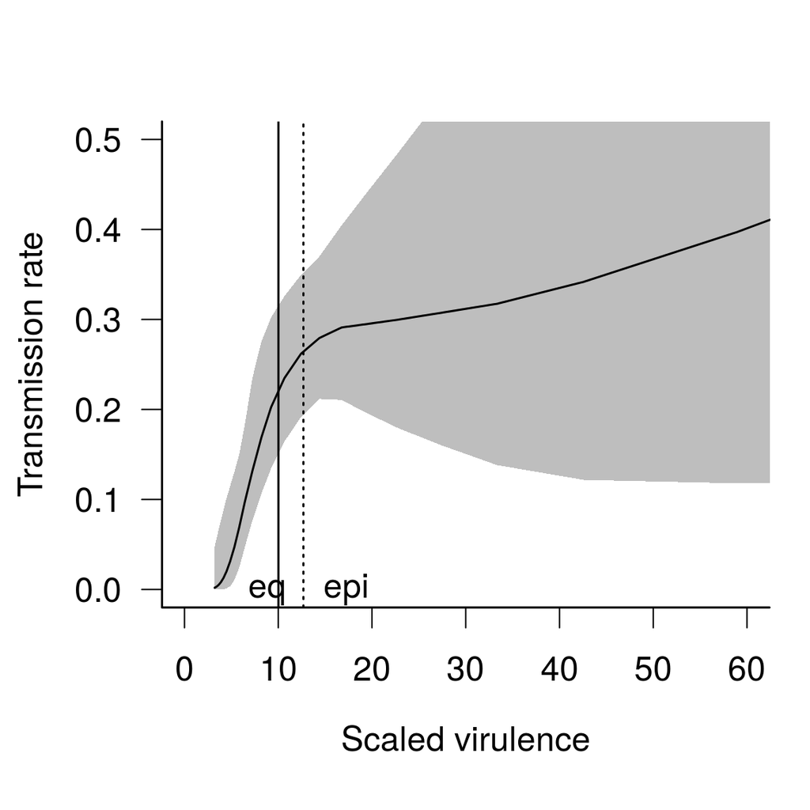

(Fraser et al. 2007)

## applications

- effects of imperfect vaccines (André et al. 2006)
- effects of long-lasting stages (Bonhoeffer et al. 1996; Gandon 1998; Kamo et al. 2004)

## the modern era

- recognition of complexity
- backlash against simple tradeoff models (Ebert et al. 2003; Alizon et al. 2015)
- more within-host dynamics (King et al. 2009; Alizon et al. 2005; Gilchrist et al. 2006)
- Price equation (Day et al. 2004)
- host factors

## complexities

- tradeoff curve may vary sensitively with within-host parameters
- interplay with other factors
  - host/parasite life history
  - seasonal variation
  - host heterogeneity
  - presence of resting stages
  - spatial (connections to game theory)

## short-sighted evolution/ accidental virulence

- dead-end hosts (West Nile)
- spillover hosts (bubonic plague)
- dead-end tissues  
  *Neisseria meningitides* (neuropathy generally)

## within-host dynamics

- within-host competition typically (?) increases virulence
- breakdown of "prudent" solutions
- increase in exploitation rate?
- but … depends on details (again):
  - may be mediated through host interactions
  - may depend on details

## spatial structure

- theory: spatial structure should select for decreased virulence
- experiment: viscosity decreases *infectivity* in meal moths (Boots et al. 2007)
- tradeoffs between virulence and movement will *lower* virulence near the edge of the wave (Osnas et al. 2015)

## demography

- decreasing population sizes *may* select for lower virulence (Lenski et al. 1994)
- bottlenecks in parasite transmission (Bergstrom et al. 1999)
- effects of epidemic fade-out ("invasion-persistence tradeoff") (King et al. 2009)

## outlook and challenges

## parameter estimation

- where do parameters come from?
  - order-of-magnitude estimates from natural history
  - ranges plus Latin hypercube sampling
  - direct measurement
  - estimation from time series

## model structure

- parasites
  - "game theoretic" (maximize \({\mathcal R}_0\))
  - adaptive-dynamic (invasibility diagrams)
  - 2-strain (or few-strain), explicit dynamics
  - Price equation/quantitative genetic (fixed variance)
  - many-strain (partial differential equation)
  - agent-based
- epidemic structure:
  - SI(R)(S) ?
  - frequency- or density-dependent?
  - vector-borne?
- hosts
  - tolerance/resistance genetics?  
    (same choices as above, plus Mendelian options …)
  - demography?
  - density-dependence?
  - heterogeneity?
  - population structure (spatial, age, etc.)?
  - multi-host community?

## where do we go from here?

- alternative approaches?
  - phylogenetic
  - bioinformatic
  - population genetic
- how do we get phenotypes?
- tie cellular/molecular processes to population level?
- is there a general theory? should there be?

## references

Alizon, S et al. 2005. *Amer Nat* 165 (6) (June): E155–E167.

Alizon, S et al. 2015. *Trends in Ecology & Evolution* 30 (5) (May): 248–254. doi:10.1016/j.tree.2015.02.009. http://linkinghub.elsevier.com/retrieve/pii/S016953471500049X.

André, JB et al. 2006. *Evolution* 60 (1) (January): 13–23.

Bergstrom, CT et al. 1999. *Proceedings of the National Academy Of Sciences of the United States Of America* 96 (9) (April): 5095–5100.

Bonhoeffer, S et al. 1996. *Proceedings: Biological Sciences* 263 (1371) (June): 715–721. doi:10.2307/50702. http://www.jstor.org/stable/50702.

Boots, M et al. 2007. *Science* 315 (5816) (March): 1284–1286.

Day, T. 2002a. *Proceedings of the Royal Society of London Series B-Biological Sciences* 269 (1498): 1317–1323.

———. 2002b. *Ecology Letters* 5 (4): 471–476.

Day, T et al. 2004. *Amer Nat* 163 (4) (April): E40–E63.

Dwyer, G et al. 1990. *Ecol Monog* 60: 423–447.

Ebert, D et al. 2003. *Trends Microbiol* 11 (1): 15–20.

Ebert, D et al. 1996. *Trends in Ecology & Evolution* 11 (2) (February): A79–A82.

Fraser, C et al. 2007. *PNAS* 104: 17441–17446.

Gandon, S. 1998. *Proceedings of the Royal Society of London Series B-Biological Sciences* 265 (1405): 1545–1552.

Gilchrist, MA et al. 2006. *Theoretical Population Biology* 69 (2) (March): 145–153.

Jensen, KH et al. 2006. *PLoS Biology* 4 (7) (July): e197.

Kamo, M et al. 2004. *Journal of Theoretical Biology* 231 (3): 435–441.

King, AA et al. 2009. *The American Naturalist* 173 (4) (April): 446–455. http://www.jstor.org/stable/10.1086/597217.

Knell, RJ. 2004. *Proc R Soc London B* 271 (May): S174–S176.

Lenski, RE et al. 1994. *J Theor Biol* 169: 253–265.

Levin, BR et al. 1990. *Parasitology* 100: S103–115.

Mackinnon, MJ et al. 1999. *Proc R Soc London B* 266 (1420) (April): 741–748.

Osnas, EE et al. 2015. *The American Naturalist* 185 (3) (March): 332–342. doi:10.1086/679734. http://www.jstor.org/stable/10.1086/679734.

Paul, REL et al. 2004. *BMC Evol Biol* 4 (September): 30.

Råberg, L. 2014. *PLoS Biol* 12 (11) (November): e1001989. doi:10.1371/journal.pbio.1001989. http://dx.doi.org/10.1371/journal.pbio.1001989.

Roy, BA et al. 2000. *Evolution* 54 (1) (February): 51–63.